# Homework 1: Linear Model Intorduction

# 4 Egg Data Plotting

Using the “Egg Data” worksheet, plot Number of Eggs vs. Length, and color code the plotted points by Region. (Note, the authors did not include a Region variable in this worksheet, so you will need to create one by referring to the other worksheets). There are many ways to do this.

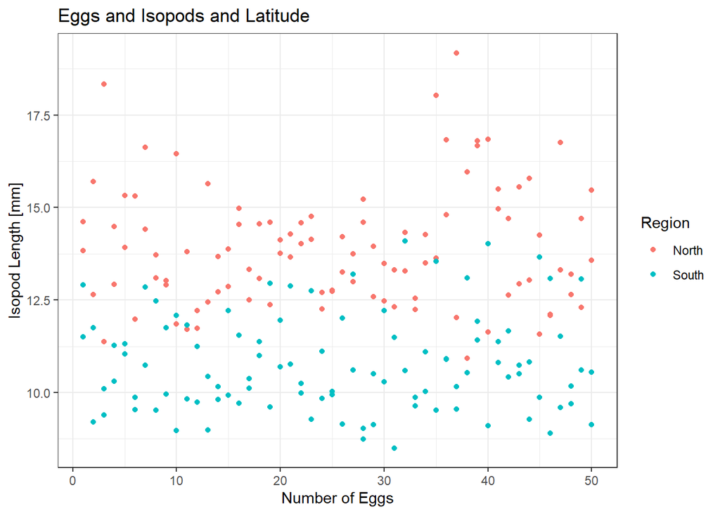

Figure 4.1: Scatter plot of Egg count and Length of Isopods across different regions (Red/Blue). Regions are North and South classifications of population location (Nahant, Magnolia, VIMS CCVA) inferred from the ‘Lab Cultures’ excel sheet.

```r
fec_egg <- read_excel(path = paste(infile, "ManyakBellSotka_AmNat_AllData.xlsx",
                                sep = ""),
                   sheet = "Egg Data")
# Creating an empty vector of NA's to fill
fec_egg$Region <- rep(NA, nrow(fec_egg))
fec_egg[fec_egg$Population == "CCVA",    ]$Region <- "South"
fec_egg[fec_egg$Population == "Magnolia",]$Region <- "North"
fec_egg[fec_egg$Population == "Nahant",  ]$Region <- "North"
fec_egg[fec_egg$Population == "VIMS",    ]$Region <- "South"
names(fec_egg)[3] = "Length"

ggplot() +
  geom_point(aes(Number,  Length, colour = Region), data = fec_egg) +
  labs(x = "Number of Eggs",
       y = "Isopod Length [mm]",
       title = "Eggs and Isopods and Latitude") +
  theme_bw()
```

# 5 Egg Data lm() and F-test

Fit a linear model to test whether the relationship between Number of Eggs and Length differs between Regions. Perform and report the appropriate F-test to test this question. How might you interpret these results?

```r
# For interaction use * not +
model <- lm(Length ~ Number*Region, data = fec_egg)
#summary(model)
atbl_egg <- round(Anova(model, type = 2), 2)
atbl_egg
```

```
## Anova Table (Type II tests)
##
## Response: Length
##               Sum Sq  Df F value Pr(>F)
## Number          0.77   1    0.35   0.55
## Region        488.52   1  224.66 <2e-16 ***
## Number:Region   0.13   1    0.06   0.81
## Residuals     426.20 196
## ---
## Signif. codes:  0 '***' 0.001 '**' 0.01 '*' 0.05 '.' 0.1 ' ' 1
```

**Answer:** To test whether the relationship between Number of Eggs and Length differs between Regions I performed a multi-way ANOVA with interaction between Length, Number, and Region. I found that the relationship between Number of Eggs and Length does not differ significantly across Region (p = 0.81). While there is a significant effect on Length by Region (p < 2e-16). This is shown in Figure 6.1 below. While the intercepts of the two trend lines (Regions effect on Length) differ greatly, the slope (interaction) are similar. Summary of the model output was done, but not displayed.

# 6 Adding lines to Egg Data

For #5 you have essentially fit two linear regressions, one for each Region. Take your plot from #4 and add these two lines.

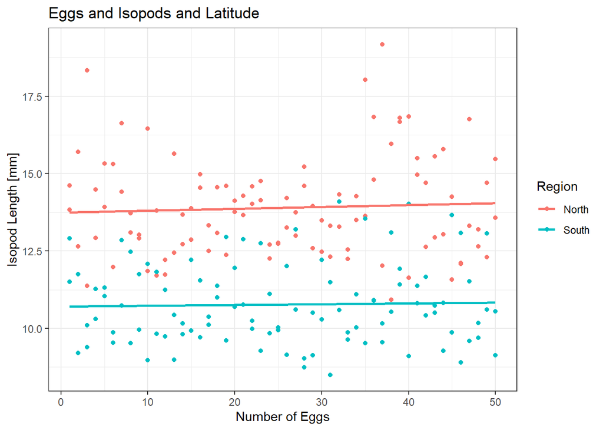

Figure 6.1: The same scatter plot as Figure 4, but with trend lines overlaid on the regional data to illustrate the results of the multi-way ANOVA on continuous/count data. While the intercepts of the two trend lines (Regions effect on Length) differ greatly, the slope (interaction) are similar.

```r
ggplot(aes(Number,  Length, colour = Region), data = fec_egg) +
  geom_point() +
  geom_smooth(method = lm, se = FALSE) +
  labs(x = "Number of Eggs",
       y = "Isopod Length [mm]",
       title = "Eggs and Isopods and Latitude") +
  theme_bw()
```